# Team4_AIT526_FinalProject

## 4.Description of the Algorithm (Step-by-Step)

- **Import Necessary Libraries**:
  - Import required Python libraries such as pandas, re, nltk, transformers, sklearn, matplotlib, seaborn, and nrclex for data manipulation, NLP tasks, sentiment/emotion analysis, visualization, and evaluation.
- **Download NLTK Resources**:
  - Download necessary NLTK datasets using nltk.download(), Tokenizers(punkt),stopwords, lemmatizer(wordnet)
- **Load Dataset**:
  - Load the sentiment dataset using pandas.read_csv().
  - Remove unwanted columns (e.g., “Unnamed”) and handle missing values in the Text column by replacing them with empty strings.
- **Text Preprocessing**:
  - Clean the text using a custom clean_text() function
    - Convert text to lowercase.
    - Remove URLs, hashtags, mentions, punctuation, numbers, and extra whitespace.
  - Store the cleaned text in a new column clean_text.
- **Lemmatization**:
  - Tokenize the cleaned text using NLTK.
  - Remove stopwords using stopwords.words('english')
  - Lemmatize each token using WordNetLemmatizer and store the processed text in the lemmatized_text column.
- **Sentiment Analysis with BERT**:
  - Apply the HuggingFace transformers pipeline using the model distilbert-base-uncased-finetuned-sst-2-english.
  - Predict sentiment for each lemmatized review and store the result in the bert_sentiment column.
  - Map BERT output labels (POSITIVE, NEGATIVE) to human-readable labels (Positive, Negative).
- **Sentiment Comparison**:
  - If the original dataset includes sentiment labels, compare them with BERT predictions.
  - Identify mismatched sentiment cases and display samples for error analysis.
- **Emotion Detection using NRCLex**:
  - Apply NRCLex to each lemmatized review to extract top emotions.
  - Save the emotion tags in the emotions column.
- **Visualization**:
  - **Word Count**:
    - Shows the distribution of word counts in lemmatized reviews.
    - Helps identify whether reviews are short or lengthy.
  - **Sentiment Distribution (BERT)**:
    - Visualizes the count of Positive vs. Negative sentiments.
    - Indicates the overall sentiment trend in the dataset.
  - **Emotion Frequency Distribution**:
    - Displays how frequently each emotion appears using NRCLex.
    - Highlights the dominant emotional tones in the text.
  - **Emotion vs Sentiment Heatmap**:
    - Cross-tabulates detected emotions with BERT sentiment labels.
    - Reveals emotional patterns behind positive and negative reviews.
  - **NRC Emotion Word Cloud**:
    - Visualizes emotion frequency using word cloud size.
    - Offers an intuitive view of common emotional tags.
  - **BERTopic Visualization**:
    - Shows the top 10 most frequent discussion topics.
    - Helps identify key themes present in the text data.
- **VADER and BERT Comparison**:
  - The results indicate that BERT outperforms VADER in terms of accuracy. BERT achieved an accuracy of 71%, while VADER's accuracy was only 43%.
  - This suggests that BERT, being a transformer-based model, provides more reliable sentiment predictions compared to the rule-based VADER approach.

## 5.Implementation Process

### 1) Load the dataset

```python
import pandas as pd

dataframe = pd.read_csv('C:/Users/nehad/Desktop/Courses/SecondSem/AIT-NLP-526/Team4-project/sentimentdataset.csv')

# Remove any unnecessary columns
dataframe.drop(columns=[col for col in dataframe.columns if 'Unnamed' in col], inplace=True)

# Fill missing text
dataframe['Text'] = dataframe['Text'].fillna('')

dataframe.head()
```

|  | Text | Sentiment | Timestamp | User | Platform | Hashtags | Retweets | Likes | Country | Year | Month | Day | Hour |
| --- | --- | --- | --- | --- | --- | --- | --- | --- | --- | --- | --- | --- | --- |
| 0 | Enjoying a beautiful day at the park! ... | Positive | 2023-01-15 12:30:00 | User123 | Twitter | #Nature #Park | 15.0 | 30.0 | USA | 2023 | 1 | 15 | 12 |
| 1 | Traffic was terrible this morning. ... | Negative | 2023-01-15 08:45:00 | CommuterX | Twitter | #Traffic #Morning | 5.0 | 10.0 | Canada | 2023 | 1 | 15 | 8 |
| 2 | Just finished an amazing workout! 💪 ... | Positive | 2023-01-15 15:45:00 | FitnessFan | Instagram | #Fitness #Workout | 20.0 | 40.0 | USA | 2023 | 1 | 15 | 15 |
| 3 | Excited about the upcoming weekend getaway! ... | Positive | 2023-01-15 18:20:00 | AdventureX | Facebook | #Travel #Adventure | 8.0 | 15.0 | UK | 2023 | 1 | 15 | 18 |
| 4 | Trying out a new recipe for dinner tonight. ... | Neutral | 2023-01-15 19:55:00 | ChefCook | Instagram | #Cooking #Food | 12.0 | 25.0 | Australia | 2023 | 1 | 15 | 19 |

### 2) Text preprocessing: Cleaning

```python
import re

def clean_text(text):
    text = text.lower()
    text = re.sub(r'http\S+|www\S+', '', text)
    text = re.sub(r'@\w+|#\w+', '', text)
    text = re.sub(r'[^\w\s]', '', text)
    text = re.sub(r'\d+', '', text)
    text = re.sub(r'\s+', ' ', text).strip()
    return text

dataframe['clean_text'] = dataframe['Text'].apply(clean_text)
dataframe[['Text', 'clean_text']].head()
```

|  | Text | clean_text |
| --- | --- | --- |
| 0 | Enjoying a beautiful day at the park! ... | enjoying a beautiful day at the park |
| 1 | Traffic was terrible this morning. ... | traffic was terrible this morning |
| 2 | Just finished an amazing workout! 💪 ... | just finished an amazing workout |
| 3 | Excited about the upcoming weekend getaway! ... | excited about the upcoming weekend getaway |
| 4 | Trying out a new recipe for dinner tonight. ... | trying out a new recipe for dinner tonight |

### 3) Text preprocessing: Lemmatization

```python
import nltk
from nltk.corpus import stopwords
from nltk.stem import WordNetLemmatizer

nltk.download('punkt')
nltk.download('stopwords')
nltk.download('wordnet')

lemmatizer = WordNetLemmatizer()
stop_words = set(stopwords.words('english'))

def lemmatize_text(text):
    tokens = nltk.word_tokenize(text)
    tokens = [lemmatizer.lemmatize(token.lower()) for token in tokens if token.lower() not in stop_words and token.isalpha()]
    return ' '.join(tokens)

dataframe['lemmatized_text'] = dataframe['clean_text'].apply(lemmatize_text)
dataframe[['clean_text', 'lemmatized_text']].head()
```

|  | clean_text | lemmatized_text |
| --- | --- | --- |
| 0 | enjoying a beautiful day at the park | enjoying beautiful day park |
| 1 | traffic was terrible this morning | traffic terrible morning |
| 2 | just finished an amazing workout | finished amazing workout |
| 3 | excited about the upcoming weekend getaway | excited upcoming weekend getaway |
| 4 | trying out a new recipe for dinner tonight | trying new recipe dinner tonight |

### 4)BERT Sentiment Classification

```python
from transformers import pipeline

# Make use of the BERT sentiment model
sentiment_model = pipeline("sentiment-analysis", model="distilbert-base-uncased-finetuned-sst-2-english")

# Use the dataset (BERT input must to be less than 512 tokens).
dataframe['bert_sentiment'] = dataframe['lemmatized_text'].apply(lambda x: sentiment_model(x[:512])[0]['label'])
dataframe['bert_sentiment'] = dataframe['bert_sentiment'].map({'POSITIVE': 'Positive', 'NEGATIVE': 'Negative'})

dataframe[['Text', 'bert_sentiment']].head()
```

```
Device set to use cpu
```

|  | Text | bert_sentiment |
| --- | --- | --- |
| 0 | Enjoying a beautiful day at the park! ... | Positive |
| 1 | Traffic was terrible this morning. ... | Negative |
| 2 | Just finished an amazing workout! 💪 ... | Positive |
| 3 | Excited about the upcoming weekend getaway! ... | Positive |
| 4 | Trying out a new recipe for dinner tonight. ... | Positive |

### 5) Error Analysis

```python
if 'Sentiment' in dataframe.columns:
    dataframe['original_sentiment'] = dataframe['Sentiment']
    error_samples = dataframe[dataframe['bert_sentiment'] != dataframe['original_sentiment']]
    display(error_samples[['Text', 'original_sentiment', 'bert_sentiment']].head(10))
```

|  | Text | original_sentiment | bert_sentiment |
| --- | --- | --- | --- |
| 0 | Enjoying a beautiful day at the park! ... | Positive | Positive |
| 1 | Traffic was terrible this morning. ... | Negative | Negative |
| 2 | Just finished an amazing workout! 💪 ... | Positive | Positive |
| 3 | Excited about the upcoming weekend getaway! ... | Positive | Positive |
| 4 | Trying out a new recipe for dinner tonight. ... | Neutral | Positive |
| 5 | Feeling grateful for the little things in lif... | Positive | Positive |
| 6 | Rainy days call for cozy blankets and hot coc... | Positive | Positive |
| 7 | The new movie release is a must-watch! ... | Positive | Positive |
| 8 | Political discussions heating up on the timel... | Negative | Positive |
| 9 | Missing summer vibes and beach days. ... | Neutral | Negative |

### 6) Emotion Detection using NRCLex

```python
from nrclex import NRCLex

def get_emotions(text):
    emotion = NRCLex(text)
    return emotion.top_emotions

dataframe['emotions'] = dataframe['lemmatized_text'].apply(lambda x: get_emotions(x))
dataframe[['lemmatized_text', 'emotions']].head()
```

|  | lemmatized_text | emotions |
| --- | --- | --- |
| 0 | enjoying beautiful day park | [(positive, 0.3333333333333333), (joy, 0.33333... |
| 1 | traffic terrible morning | [(fear, 0.2), (anger, 0.2), (negative, 0.2), (... |
| 2 | finished amazing workout | [(fear, 0.0), (anger, 0.0), (anticip, 0.0), (t... |
| 3 | excited upcoming weekend getaway | [(trust, 0.2), (surprise, 0.2), (positive, 0.2... |
| 4 | trying new recipe dinner tonight | [(positive, 1.0)] |

### 7) Visualization

#### 1. Word Count

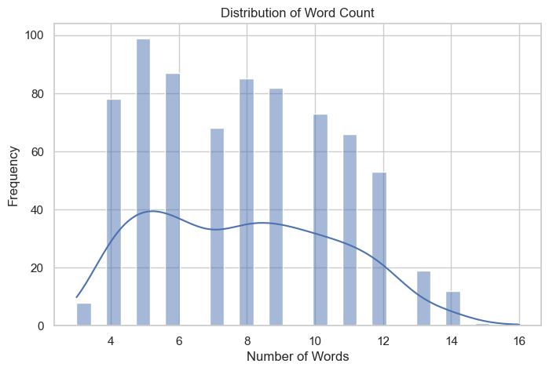

```python
dataframe['word_count'] = dataframe['lemmatized_text'].apply(lambda x: len(x.split()))

import matplotlib.pyplot as plt
import seaborn as sns

plt.figure(figsize=(8,5))
sns.histplot(dataframe['word_count'], bins=30, kde=True)
plt.title('Distribution of Word Count')
plt.xlabel('Number of Words')
plt.ylabel('Frequency')
plt.show()
```

#### 2. Sentiment Distribution (BERT)

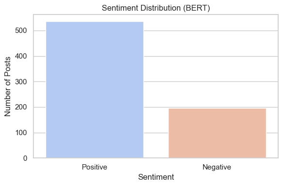

```python
sentiment_counts = dataframe['bert_sentiment'].value_counts()
sentiment_dataframe = sentiment_counts.reset_index()
sentiment_dataframe.columns = ['sentiment', 'count']

plt.figure(figsize=(6, 4))
sns.barplot(data=sentiment_dataframe, x='sentiment', y='count', hue='sentiment', palette='coolwarm', legend=False)
plt.title('Sentiment Distribution (BERT)')
plt.ylabel('Number of Posts')
plt.xlabel('Sentiment')
plt.tight_layout()
plt.show()
```

#### 3. Emotion Frequency Distribution

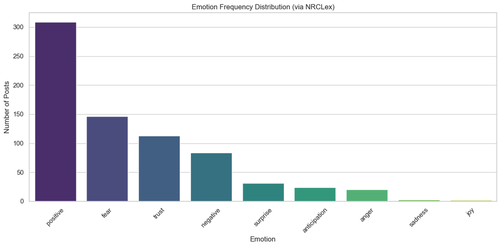

```python
from nrclex import NRCLex

def detect_emotion(text):
    emotion = NRCLex(text)
    if emotion.top_emotions:
        return emotion.top_emotions[0][0]
    else:
        return "neutral"

# Create the emotion column (if not exists)
dataframe['emotion'] = dataframe['Text'].apply(detect_emotion)

emotion_counts = dataframe['emotion'].value_counts()
emotion_dataframe = pd.DataFrame(list(emotion_counts.items()), columns=['emotion', 'count'])

# Plot
plt.figure(figsize=(12, 6))
sns.barplot(data=emotion_dataframe, x='emotion', y='count', hue='emotion', palette='viridis', legend=False)
plt.title('Emotion Frequency Distribution (via NRCLex)')
plt.xlabel('Emotion')
plt.ylabel('Number of Posts')
plt.xticks(rotation=45)
plt.tight_layout()
plt.show()
```

#### 4. Emotion vs Sentiment Heatmap

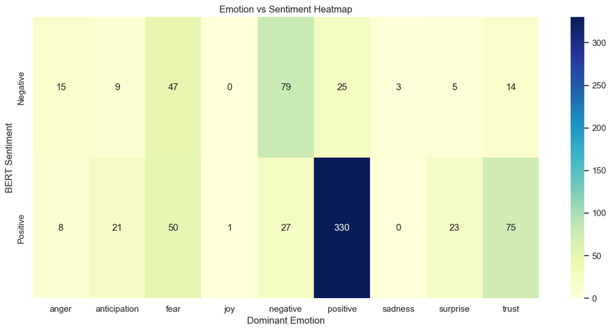

```python
dataframe['dominant_emotion'] = dataframe['emotions'].apply(
    lambda x: x[0][0] if isinstance(x, list) and len(x) > 0 else 'unknown'
)
# heatmap
heat_data = pd.crosstab(dataframe['bert_sentiment'], dataframe['dominant_emotion'])

plt.figure(figsize=(12,6))
sns.heatmap(heat_data, cmap='YlGnBu', annot=True, fmt='d')
plt.title('Emotion vs Sentiment Heatmap')
plt.ylabel('BERT Sentiment')
plt.xlabel('Dominant Emotion')
plt.tight_layout()
plt.show()
```

#### 5. NRC Emotion Word Cloud

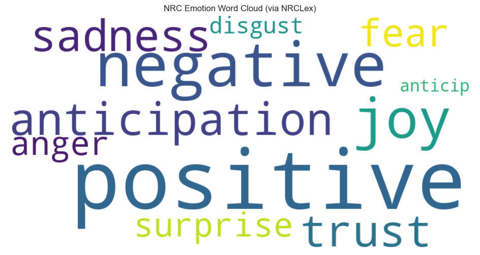

```python
from wordcloud import WordCloud
import matplotlib.pyplot as plt
import pandas as pd

all_emotions = []

for emo_list in dataframe['emotions'].dropna():
    if isinstance(emo_list, list):
        for tup in emo_list:
            if isinstance(tup, tuple) and len(tup) == 2:
                all_emotions.append(tup[0])  # Extract emotion label

# frequency count
emotion_counts = pd.Series(all_emotions).value_counts().to_dict()

# Create a word cloud.
wordcloud = WordCloud(width=800, height=400, background_color='white').generate_from_frequencies(emotion_counts)


plt.figure(figsize=(12, 6))
plt.imshow(wordcloud, interpolation='bilinear')
plt.axis('off')
plt.title("NRC Emotion Word Cloud (via NRCLex)")
plt.show()
```

#### 6. BERTopic Visualization

```python
from bertopic import BERTopic
# Adjust the model
topic_model = BERTopic()
topics, probs = topic_model.fit_transform(dataframe['lemmatized_text'])

# Include topics in the dataframe
dataframe['bertopic_topic'] = topics
# Topics that are most frequently discussed
topic_model.visualize_barchart(top_n_topics=10)
```

[interactive chart not shown]

## VADER and BERT comparison

```
Class distribution after filtering:
Sentiment
positive    45
neutral     18
negative     4
Name: count, dtype: int64

VADER Accuracy: 0.43
```

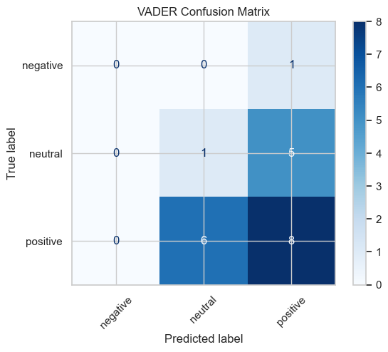

```
Device set to use cpu
```

```
 BERT Accuracy: 0.71
```

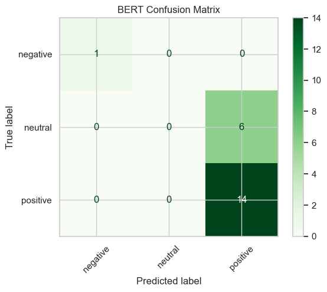

```
 Model Accuracy Comparison
-----------------------------
VADER Accuracy: 0.43
BERT Accuracy : 0.71
```

```python
# Imports
import numpy as np
import matplotlib.pyplot as plt
from sklearn.model_selection import train_test_split
from sklearn.metrics import accuracy_score, confusion_matrix, ConfusionMatrixDisplay
from sklearn.preprocessing import LabelEncoder

# VADER
from vaderSentiment.vaderSentiment import SentimentIntensityAnalyzer

# BERT
from transformers import pipeline
import torch

df.dropna(subset=["Text", "Sentiment"], inplace=True)
df["Sentiment"] = df["Sentiment"].str.strip().str.lower()

valid_classes = ["positive", "neutral", "negative"]
df = df[df["Sentiment"].isin(valid_classes)]

print("Class distribution after filtering:")
print(df["Sentiment"].value_counts())

# Train-Test Split (70% train, 30% test)
X_train, X_test, y_train, y_test = train_test_split(
    df["Text"], df["Sentiment"], test_size=0.3, random_state=42, stratify=df["Sentiment"]
)

# labels for metric calculations
le = LabelEncoder()
y_test_encoded = le.fit_transform(y_test)


#  VADER Sentiment Analysis
analyzer = SentimentIntensityAnalyzer()

def vader_predict(text):
    score = analyzer.polarity_scores(text)["compound"]
    if score >= 0.05:
        return "positive"
    elif score <= -0.05:
        return "negative"
    else:
        return "neutral"

vader_preds = X_test.apply(vader_predict)
vader_preds_encoded = le.transform(vader_preds)

# Metrics
vader_acc = accuracy_score(y_test_encoded, vader_preds_encoded)
vader_cm = confusion_matrix(y_test_encoded, vader_preds_encoded)
print(f"\nVADER Accuracy: {vader_acc:.2f}")

# Plot VADER Confusion Matrix
disp = ConfusionMatrixDisplay(confusion_matrix=vader_cm, display_labels=le.classes_)
disp.plot(xticks_rotation=45, cmap="Blues")
plt.title("VADER Confusion Matrix")
plt.show()


# BERT Sentiment Analysis
# Explicitly specify the model
classifier = pipeline("sentiment-analysis", model="distilbert-base-uncased-finetuned-sst-2-english")

def map_bert_label(label):
    label = label.lower()
    if label in ["positive", "negative"]:
        return label
    else:
        return "neutral"

bert_preds = X_test.apply(lambda x: map_bert_label(classifier(x)[0]['label']))
bert_preds_encoded = le.transform(bert_preds)

# Metrics
bert_acc = accuracy_score(y_test_encoded, bert_preds_encoded)
bert_cm = confusion_matrix(y_test_encoded, bert_preds_encoded)
print(f"\n BERT Accuracy: {bert_acc:.2f}")

# Plot BERT Confusion Matrix
disp = ConfusionMatrixDisplay(confusion_matrix=bert_cm, display_labels=le.classes_)
disp.plot(xticks_rotation=45, cmap="Greens")
plt.title("BERT Confusion Matrix")
plt.show()


# Final Comparison Summary
print("\n Model Accuracy Comparison")
print("-----------------------------")
print(f"VADER Accuracy: {vader_acc:.2f}")
print(f"BERT Accuracy : {bert_acc:.2f}")
```

```python
# Create a CSV file containing the final dataframe with all of the results.
dataframe.to_csv('C:/Users/nehad/Desktop/Courses/SecondSem/AIT-NLP-526/Team4-project/final_output_checkpoint3.csv', index=False)
```